# Data Visualization on Honey Production dataset using seaborn and matplotlib libraries.

## Domain: Food and agriculture

## Context:

In 2006, a global concern was raised over the rapid decline in the honeybee population, an integral component to American honey agriculture. Large numbers of hives were lost to “Colony-Collapse-Disorder”, a phenomenon of disappearing “worker-bees” causing the remaining “hive-colony” to collapse. Speculation around the cause of this disorder points to hive-diseases and pesticides harming the pollinators, though no overall consensus has been reached. Twelve years later, some industries are observing recovery but the American honey industry is still largely struggling. The U.S. used to locally produce over half the honey it consumes per year. Now, honey mostly comes from overseas, with 350 of the 400 million pounds of honey consumed every year originating from imports. This dataset provides insight into honey production supply and demand in America by state from 1998 to 2012.

## Objective:

The Goal is to use Python visualization libraries such as seaborn and matplotlib to investigate the data and get some useful conclusions.

## Attribute Information:

| Slno. | Attribute | Description |
| --- | --- | --- |
| 1 | numcol | Number of honey producing colonies. |
| 2 | yield percol | Honey yield per colony. (Unit is pounds) |
| 3 | total prod | Total production (numcol x yieldpercol). (Unit is pounds) |
| 4 | price per lb | Refers to average price per pound based on expanded sales. Unit is dollars. |
| 5 | prodvalue | Value of production (total prod x priceperlb). Unit is dollars. |
| 6 | Stocks | Refers to stocks held by producers. Unit is pounds |
| 7 | Year | Calendar year. |
| 8 | State | Different states' names. |

### 1. Import required libraries and read the dataset.

```python
import numpy as np
import pandas as pd

import seaborn as sns
import matplotlib.pyplot as plt
```

```python
data = pd.read_csv('honeyproduction.csv')
```

### 2. Check the first few samples, shape, info of the data and try to familiarize yourself with different features.

```python
data.head()
```

|  | state | numcol | yieldpercol | totalprod | stocks | priceperlb | prodvalue | year |
| --- | --- | --- | --- | --- | --- | --- | --- | --- |
| 0 | AL | 16000.0 | 71 | 1136000.0 | 159000.0 | 0.72 | 818000.0 | 1998 |
| 1 | AZ | 55000.0 | 60 | 3300000.0 | 1485000.0 | 0.64 | 2112000.0 | 1998 |
| 2 | AR | 53000.0 | 65 | 3445000.0 | 1688000.0 | 0.59 | 2033000.0 | 1998 |
| 3 | CA | 450000.0 | 83 | 37350000.0 | 12326000.0 | 0.62 | 23157000.0 | 1998 |
| 4 | CO | 27000.0 | 72 | 1944000.0 | 1594000.0 | 0.70 | 1361000.0 | 1998 |

```python
data.tail()
```

|  | state | numcol | yieldpercol | totalprod | stocks | priceperlb | prodvalue | year |
| --- | --- | --- | --- | --- | --- | --- | --- | --- |
| 621 | VA | 4000.0 | 41 | 164000.0 | 23000.0 | 3.77 | 618000.0 | 2012 |
| 622 | WA | 62000.0 | 41 | 2542000.0 | 1017000.0 | 2.38 | 6050000.0 | 2012 |
| 623 | WV | 6000.0 | 48 | 288000.0 | 95000.0 | 2.91 | 838000.0 | 2012 |
| 624 | WI | 60000.0 | 69 | 4140000.0 | 1863000.0 | 2.05 | 8487000.0 | 2012 |
| 625 | WY | 50000.0 | 51 | 2550000.0 | 459000.0 | 1.87 | 4769000.0 | 2012 |

```python
data.shape
```

```
(626, 8)
```

```python
data.info()
```

```
<class 'pandas.core.frame.DataFrame'>
RangeIndex: 626 entries, 0 to 625
Data columns (total 8 columns):
 #   Column       Non-Null Count  Dtype
---  ------       --------------  -----
 0   state        626 non-null    object
 1   numcol       626 non-null    float64
 2   yieldpercol  626 non-null    int64
 3   totalprod    626 non-null    float64
 4   stocks       626 non-null    float64
 5   priceperlb   626 non-null    float64
 6   prodvalue    626 non-null    float64
 7   year         626 non-null    int64
dtypes: float64(5), int64(2), object(1)
memory usage: 39.3+ KB
```

### 3. Display the percentage distribution of the data in each year using the pie chart.

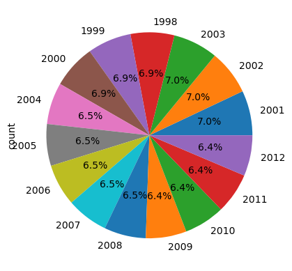

```python
data['year'].value_counts().plot(kind='pie', autopct='%1.1f%%')
```

### 4. Plot and Understand the distribution of the variable "price per lb" using displot, and write your findings.

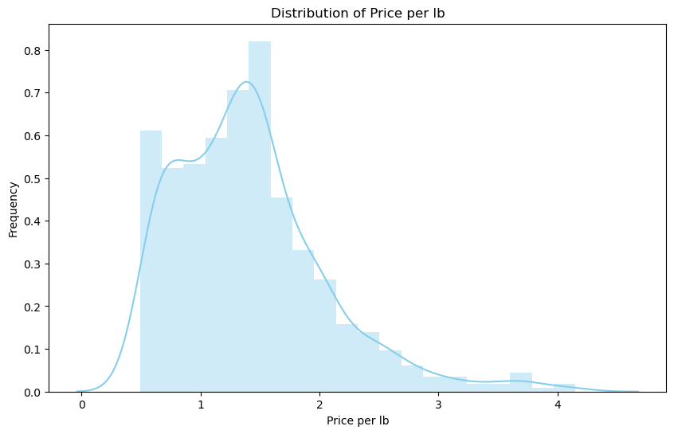

```python
# Plotting the distribution of "price per lb"
plt.figure(figsize=(10, 6))
sns.distplot(data['priceperlb'], bins=20, kde=True, color='skyblue')
plt.title('Distribution of Price per lb')
plt.xlabel('Price per lb')
plt.ylabel('Frequency')
plt.show()
```

#### Inferences:

- The distribution of the variable **price per lb** is **Right Skewed** distribution or it has positive skewness.
- **Majority of Prices are Lower:** The majority of honey prices per pound tend to be on the lower side. This is indicated by the longer right tail, suggesting that there are relatively few instances of high prices.
- **Few Instances of High Prices:** While most prices are lower, there are some instances where the price per pound is significantly higher. These could be considered as outliers or instances of premium-priced honey.
- **Potential for Outliers:** Positive skewness often indicates the presence of outliers on the higher end of the distribution. Investigate these outliers to understand the factors contributing to exceptionally high prices.

### 5. Plot and understand the relationship between the variables 'numcol' and 'prodval' through scatterplot, and write your findings.

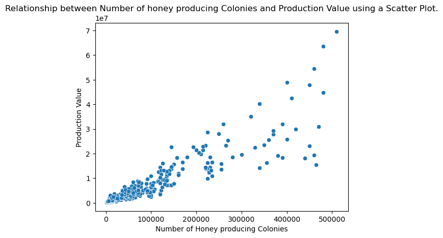

```python
sns.scatterplot(data=data, x='numcol', y='prodvalue')
plt.xlabel('Number of Honey producing Colonies')
plt.ylabel('Production Value')
plt.title('Relationship between Number of honey producing Colonies and Production Value using a Scatter Plot.')
plt.show()
```

#### Inferences:

- We can observe that there is a upward trend with a positive slope for the above scatter plot.
- It means that as number of honey producing colonies increases production value of honey also increases and vice-versa.

### 6. Plot and understand the relationship between categorical variable 'year' and a numerical variable 'prodvalue' through boxplot, and write your findings.

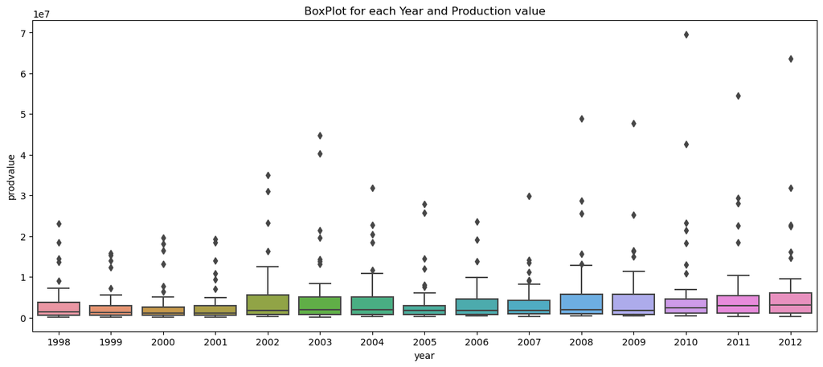

```python
plt.figure(figsize=(15, 6))
sns.boxplot(data=data, x='year', y='prodvalue')
plt.title('BoxPlot for each Year and Production value')
plt.show()
```

### 7. Visualize and understand the relationship between the multiple pairs of variables throughout different years using pairplot and add your inferences. (use columns 'numcol', 'yield percol', 'total prod', 'prodvalue','year')

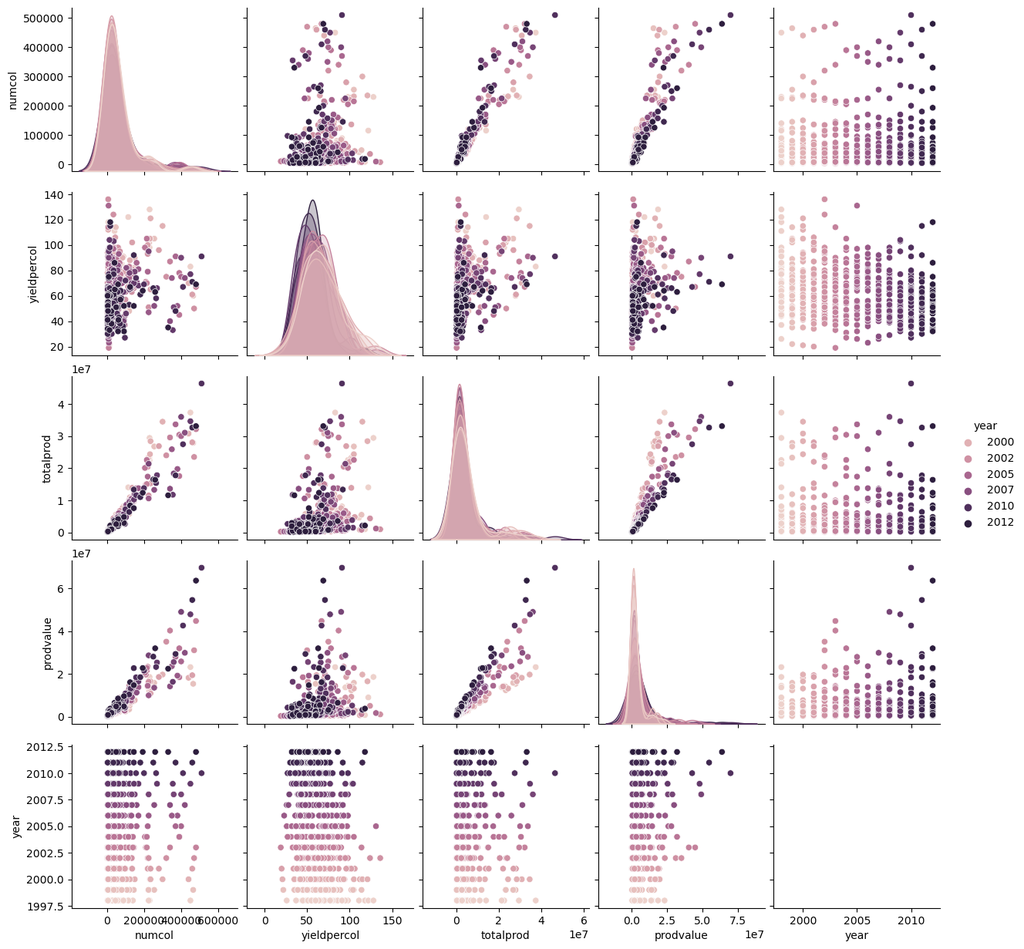

```python
sns.pairplot(data, vars=['numcol', 'yieldpercol', 'totalprod', 'prodvalue', 'year'], hue='year')
```

#### Inferences:

- The is a positive relation between (numcol, prodvalue) and (numcol, totalprod). As one value increases the other value also increases and as one decreases other also decreases.
- And also there is a positive trend between totalprod and prodvalue as on increases the other increases and vice-versa.

### 8. Display the correlation values using a plot and add your inferences. (use columns 'numcol', 'yield percol','total prod', 'stocks', 'price per lb', 'prodvalue')

```python
data[['numcol', 'yieldpercol', 'totalprod', 'stocks', 'priceperlb', 'prodvalue']].corr()
```

|  | numcol | yieldpercol | totalprod | stocks | priceperlb | prodvalue |
| --- | --- | --- | --- | --- | --- | --- |
| numcol | 1.000000 | 0.243515 | 0.953594 | 0.825929 | -0.232701 | 0.912796 |
| yieldpercol | 0.243515 | 1.000000 | 0.396252 | 0.367812 | -0.358646 | 0.278977 |
| totalprod | 0.953594 | 0.396252 | 1.000000 | 0.878830 | -0.264499 | 0.907236 |
| stocks | 0.825929 | 0.367812 | 0.878830 | 1.000000 | -0.305867 | 0.728560 |
| priceperlb | -0.232701 | -0.358646 | -0.264499 | -0.305867 | 1.000000 | -0.089567 |
| prodvalue | 0.912796 | 0.278977 | 0.907236 | 0.728560 | -0.089567 | 1.000000 |

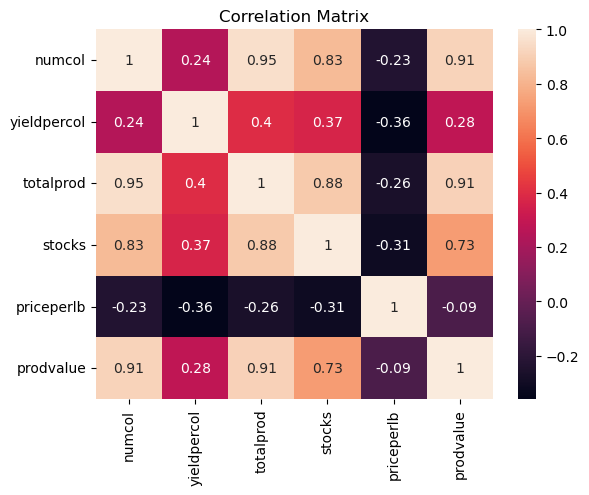

```python
sns.heatmap(data[['numcol', 'yieldpercol', 'totalprod', 'stocks', 'priceperlb', 'prodvalue']].corr(), annot=True)
plt.title("Correlation Matrix")
plt.show()
```